# Mapping overdoses in Cincinnati

Today we will analyze data from the Cincinnati Fire Incidents database. The database is publicly available and can be downloaded here: https://data.cincinnati-oh.gov/Safer-Streets/Cincinnati-Fire-Incidents-CAD-including-EMS-ALS-BL/vnsz-a3wp

The city also has a nice graphical interface for mapping and exploring these data. https://insights.cincinnati-oh.gov/stories/s/Heroin-Overdose-Responses/dm3s-ep3u/

These data contain a record of emergency medical service calls, including fires, rescues and other fire department-related services. Our goal will be to examine spatial and spatiotemporal clusters

## First up: Why does harmonic regression work?

It is a bit counterintuitive–we are using (linear) regression but seemingly getting out a prediction that is not a straight line. What gives? It has to do with the fact that what we are plotting is not the same as what we are putting into the regression model.

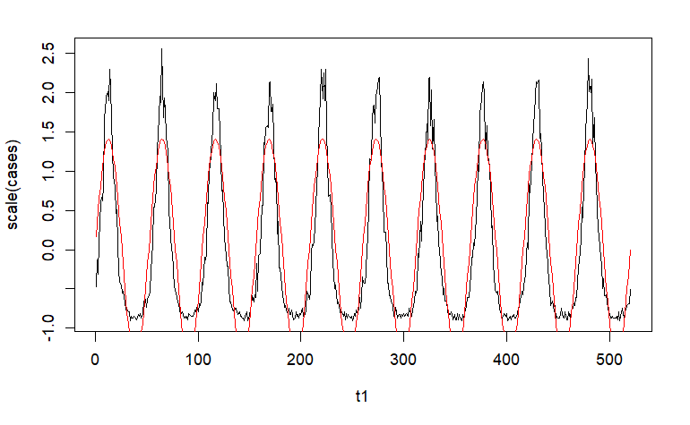

```r
plot(t1,scale(cases), type='l')
points(t1, scale(temperature), col='red' , type='l')
```

But when we fit a regression, we are fitting Y~x, in this instance, cases~ temperature. Here we can see that there is a strong correlation between cases and temperature. This relationship is what is being fit with the regression. But when we plot it as a function of time, both X and Y will follow that harmonic shape. With the harmonic regression approach, we use a combination of sine and cosine terms, rather than temperature, to capture this type of variation, but the idea is the same, when the sine/cosine wave increases, cases increase

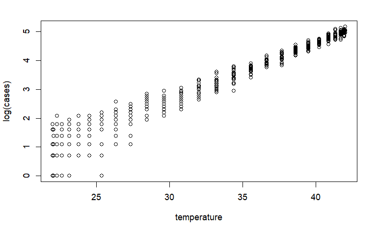

```r
plot(temperature ,log(cases))
```

```r
# cin1 <- read.csv('https://data.cincinnati-oh.gov/api/views/vnsz-a3wp/rows.csv?accessType=DOWNLOAD')
#
# cin1a <- cin1[,c('LATITUDE_X', 'LONGITUDE_X', 'CREATE_TIME_INCIDENT', 'ARRIVAL_TIME_PRIMARY_UNIT', 'CFD_INCIDENT_TYPE_GROUP',"COMMUNITY_COUNCIL_NEIGHBORHOOD")]
#
# saveRDS(cin1a,'./Data/cincinnati.rds')


cin1 <- readRDS('./Data/cincinnati.rds')
```

## Let’s first have a look at what variables are in the dataset

```r
names(cin1)
```

```r
View(cin1)
```

What are the different types of calls in the database?

```r
sort(
  table(
    cin1$CFD_INCIDENT_TYPE_GROUP #what variable are we tabulating?
    ),
  decreasing=T) #biggest to smallest sort
```

## Format the date and time variables

```r
cin1$CREATE_TIME_INCIDENT <- as.character(cin1$CREATE_TIME_INCIDENT) #convert date-time to a character vector
```

Declare “CREATE_TIME_INCIDENT” as a date-time variable

```r
cin1$datetime <- as.POSIXct(cin1$CREATE_TIME_INCIDENT, format = "%m/%d/%Y %I:%M:%S %p")
```

Extract the date from the date-time object

```r
cin1$date <- as.Date(cin1$datetime)
```

Round date down to most reent Sunday to group by week

```r
cin1$weekdate <- floor_date(cin1$date, unit='week') #round date down to nearest Sunday, add it to the cin1 data frame
```

Pull out the hour of the incident

```r
cin1$hour <- hour(cin1$datetime)
```

## Let’s subset to just the overdose data

```r
op1 <- cin1[cin1$CFD_INCIDENT_TYPE_GROUP=='HEROIN OVERDOSE',] #pull out rows where incident type is heroin overdose
```

#Also subset out breathing problem complaints We will use this later on for our SATSCAN analysis…

```r
br1<-cin1[cin1$CFD_INCIDENT_TYPE_GROUP=='BREATHING PROBLEMS',]
```

## distribution of the dates

```r
hist(op1$date, breaks=98) #histogram with 98 bins
```

[output not shown]

#Look at distribution of overdoses over time

```r
hist(op1$hour, breaks=24, freq=T) #histogram with 24 breaks. x axis shows hours from 12:01am-11:59pm
```

[output not shown]

## Simple maps

What we will do here is just make an X-Y plot with latitude on the y axis and longitude on the x axis. For each overdose, we will make a dot.

```r
plot(op1$LONGITUDE_X, #x variable
     op1$LATITUDE_X , #Y variable
     pch=16,  #shape of the markers
     cex=0.5, #size of the marker
     col='black',  #specify a black marker
     bty='l')
```

```r
p1 <- ggplot(op1, aes(x=LONGITUDE_X, y=LATITUDE_X)) +
  geom_point() +
  theme_classic()

p1
```

[output not shown]

```r
col.plot=rgb(1,0,0,alpha=0.02) #red, with transparency

p2 <- ggplot(op1, aes(x=LONGITUDE_X, y=LATITUDE_X)) +
  geom_point( col=col.plot) +
  theme_classic()

p2
```

#Lets add in neighborhood boundaries This shows a ‘hotspot’ in downtown Cincinnatti. Even without doing any fancy statistics we can start to see some patterns

Read in a file that has map coordinates for neighborhood boundaries. This file comes from the Zillow real estate website.

Import the shape file, ‘fortify’ it so that ggplot can use it,

```r
shp.cin<-readRDS( './Data/cincinnati_neighborhood.map.rds')

shp.cin2 <-fortify(shp.cin)
```

Then add the boundaries to the points using geom_polygon()

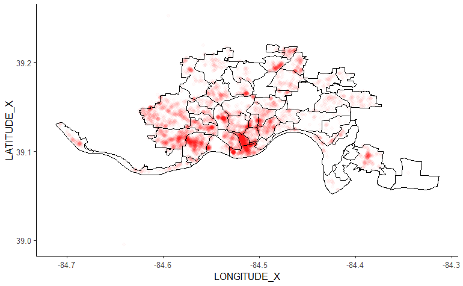

```r
p2 +
    geom_polygon(data=shp.cin2, aes(x=long, y=lat, group=group), fill=NA, colour='black', alpha=0)
```

## As a comparison, let’s look at breathing issues

```r
col.plot2=rgb(0,0,1,alpha=0.02) #blue, with transparency

p3 <- ggplot(br1, aes(x=LONGITUDE_X, y=LATITUDE_X)) +
  geom_point( col=col.plot2) +
  theme_classic() +
  ylim(min=min(shp.cin2$lat), max=max(shp.cin2$lat)) +
  geom_polygon(data=shp.cin2, aes(x=long, y=lat, group=group), fill=NA, colour='black', alpha=0)

p3
```

[output not shown]

## Prepare data for SATSCAN to detect spatiotemporal clusters

We will run 3 analyses in SATSCAN:

1. A purely temporal analysis to look for temporal clusters
2. A space-time permutation analysis to look for space-time cluster

3.A purely spatial analysis using breathing conditions as controls and heroin overdoses as cases. For the purely spatial analysis, because we are using point data, we don’t have a population denominator, so a trick is to use a different event (breathing problems) to adjust for spatial variation in population. We perform a ‘casecontrol’ analysis where we are evaluating the probability of detecting a case vs control in each of the circles.

What are the advantages and disadvantages of this?

1)Create an identifier for each event This will just be an index variable. We will combine together the heroin overdoses and breathing complaints into a single data frame so that we have unique IDs for all cases and controls.

```r
all<-rbind.data.frame(op1, br1)

all$id<-1:nrow(all)
```

1a) Remove rows without coordinate data, restrict to 2019-2022

```r
all.nomiss<-all[!is.na(all$LATITUDE_X) & all$date>= '2019-01-01',]
```

2a) create a case file

```r
op.case<-all.nomiss[all.nomiss$CFD_INCIDENT_TYPE_GROUP=='HEROIN OVERDOSE',c('id','date')]

write.csv(op.case,'./SATSCAN_inputs/op.case.csv')
```

2b) create a control file

```r
br.case<-all.nomiss[all.nomiss$CFD_INCIDENT_TYPE_GROUP=='BREATHING PROBLEMS',c('id','date')]

write.csv(br.case,'./SATSCAN_inputs/br.control.csv')
```

3. create a geo file

```r
all.geo<-all.nomiss[,c('id',"LATITUDE_X", "LONGITUDE_X"  )]
write.csv(all.geo,'all.geo.csv')

#output just the opiod coordinates
op.geo<-all.nomiss[all.nomiss$CFD_INCIDENT_TYPE_GROUP %in% c('HEROIN OVERDOSE','BREATHING PROBLEMS'),c('id',"LATITUDE_X", "LONGITUDE_X"  )]
write.csv(op.geo,'./SATSCAN_inputs/op.geo.csv')
```

5a) See results of your space-time permutation analysis here: Remember that these are space-time clusters, so hey occur for a distinct point in time, so might not line up perfectly with areas with high incidence on average.

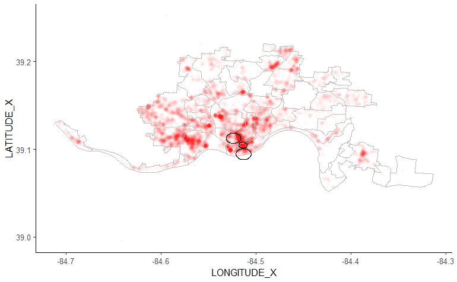

```r
space.time.shp<- shapefile('./SATSCAN_outputs/space_time_permutation/cin space time.col.shp')

space.time.shp <- fortify(space.time.shp)
p2 +
  geom_polygon(data=shp.cin2, aes(x=long, y=lat, group=group), fill=NA, colour='gray', alpha=0) +
  geom_polygon(data=space.time.shp[space.time.shp$group %in% c('0.1','1.1', '2.1'),], aes(x=long, y=lat, group=group), fill=NA, colour='black', alpha=0)
```

5b) See results of the pre-run purely spatial case-control analysis here:

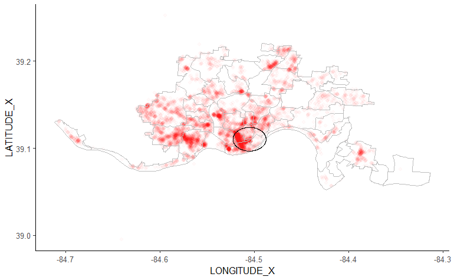

```r
case.control.shp<- shapefile('./SATSCAN_outputs/spatial/space.col.shp')

case.control.shp <- fortify(case.control.shp)
p2 +
  geom_polygon(data=shp.cin2, aes(x=long, y=lat, group=group), fill=NA, colour='gray', alpha=0) +
  geom_polygon(data=case.control.shp[case.control.shp$group %in% c('0.1'),], aes(x=long, y=lat, group=group), fill=NA, colour='black', alpha=0)
```

## Let’s also set up a CUSUM algorithm for rapid detection of overdoses

First, aggregate by day, and fill missing days with 0s to get a complete time series

```r
op2 <- op1 %>%
  group_by(date) %>%
  summarize(N_OD= n()) %>%
  ungroup() %>%
  tidyr::complete(date=seq.Date(min(date, na.rm=T), max(date, na.rm=T), 'day'), fill=list(N_OD=0)) #fills 0s

op2 <- as.data.frame(op2)
```

How many overdoses per day?

```r
hist(op2$N_OD)

median(op2$N_OD)
```

```r
glrpois_App(ds=op2, datevar='date', casevar='N_OD',n.weeks.train=365*4)
```